# Regression Basics

UBDS^3

Robert Gentleman

2026-07-14

## Outline

- basic ideas behind statistical methods
- why regression is an important tool for understanding data
- how to fit and interpret some regression models

## Where do data come from?

- experiments where someone has performed a task, usually varying some of the treatments or exposures and measuring outputs
- random sampling of some reasonably well defined population with the intention of making valid statements about that population
- clinical trials are like experiments but we don’t control how the patients are selected

## Basics of Statistical Methods

- when data are generated with variability we must account for that variation in our interpretation
- suppose we want to compare the cost to rent an apartment in two different cites
- in city A we sample 100 renters and get the mean rent per month of $500
- in city B we sample 100 renters and get the mean rent per month of $800
- which city is most expensive to rent in?
- you can’t tell without knowing how much variation there is

## Basics of Statistical Methods

- *Statistics is about coming to conclusions in the face of uncertainty*, Wild and Seber, 2000.
- given data that are measured with error we need to extract information and estimate uncertainty
- we use models to help better estimate quantities of interest when they are affected by other factors
- A challenging part of the analysis is to identify the appropriate way to estimate the variation in the data
- Failing to do these steps well means you can (and often do) get the wrong answer.

## Case study: is height hereditary?

- To understand the concepts of correlation and simple regression, we actually use the dataset from which regression was born.
- The example is from genetics.
- Francis Galton studied the variation and heredity of human traits.
- Among many other traits, Galton collected and studied height data from families to try to understand heredity.

## Case study: is height hereditary?

- While doing this, he developed the concepts of correlation and regression.
- At the time this data was collected, our knowledge of genetics was limited compared to what we know today.
- A very specific question Galton tried to answer was: **how well can we predict a child’s height based on the parents’ height?**

## Case study: is height hereditary?

- We have access to Galton’s family height data through the **HistData** package.
- This data contains heights on several dozen families: mothers, fathers, daughters, and sons.
- To imitate Galton’s analysis, we will create a dataset with the heights of fathers and a randomly selected son of each family:
- Suppose we were asked to summarize the father and son data.

```
# A tibble: 1 × 4
  `mean(father)` `sd(father)` `mean(son)` `sd(son)`
           <dbl>        <dbl>       <dbl>     <dbl>
1           69.1         2.55        69.2      2.71
```

## Case study: is height hereditary?

- This summary fails to describe an important characteristic of the data:

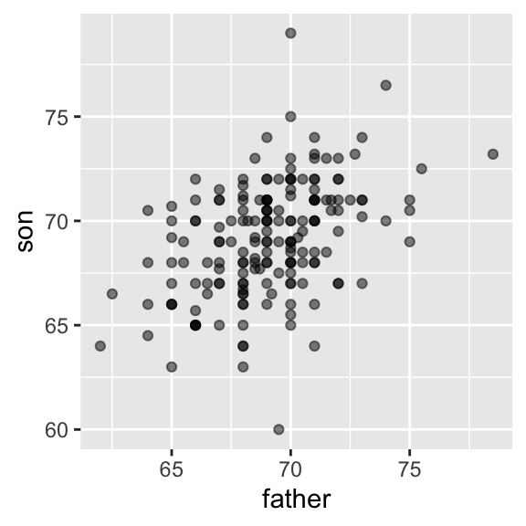

## The correlation coefficient

```r
galton_heights |> summarize(r = cor(father, son)) |> pull(r)
```

```
[1] 0.433
```

## The correlation coefficient

- Correlations ranging from -0.9 to 0.99:

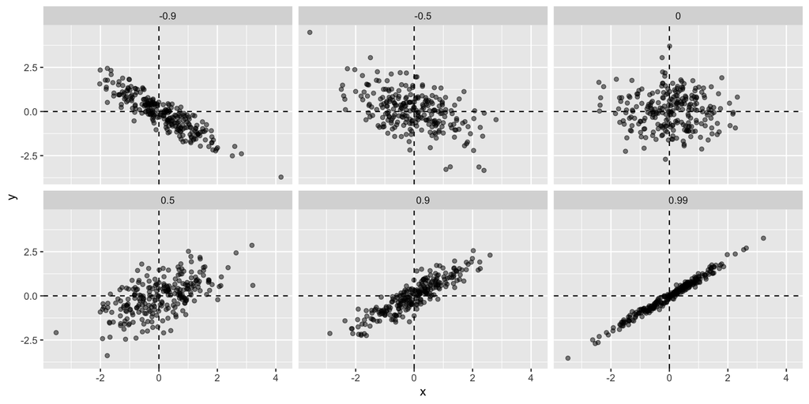

## Sample correlation is random

- Before we continue connecting correlation to regression, let’s remind ourselves about random variability.
- In most applications, we observe data that includes random variation.
- For example, in many cases, we do not observe data for the entire population of interest, but rather for a random sample.
- As with the average and standard deviation, the *sample correlation* is the most commonly used estimate of the population correlation.

## Sample correlation is random

- while the true correlation in the population is fixed but unkownn
- the correlation we compute on the sample and use as a summary is a random variable.
- By way of illustration, let’s assume that the 179 pairs of fathers and sons is our entire population.
- A less fortunate geneticist can only afford measurements from a random sample of 25 pairs.
- The sample correlation can be computed with:

```r
r <- sample_n(galton_heights, 25, replace = TRUE) |>
  summarize(r = cor(father, son)) |> pull(r)
```

- `r` is a random variable.

## Sample correlation is random

- We can run a Monte Carlo simulation to see its distribution:

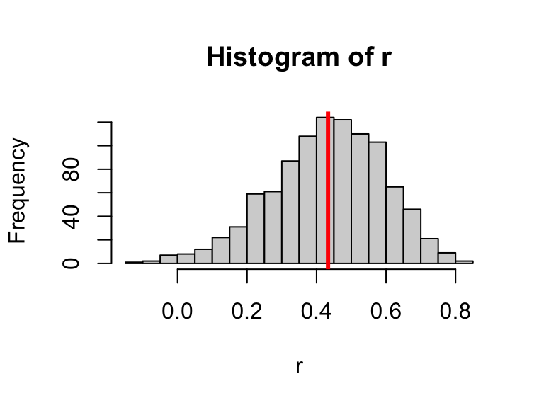

[figure not shown]

## Sample correlation is random

- We see that the observed mean of `r` is close to the population correlation of $0.433$

```
[1] 0.431
```

- and that the standard error is large relative to the range of values `r` can take:

```
[1] 0.161
```

- So, when interpreting correlations, remember that correlations derived from samples are estimates with uncertainty.

## Correlation is not always useful

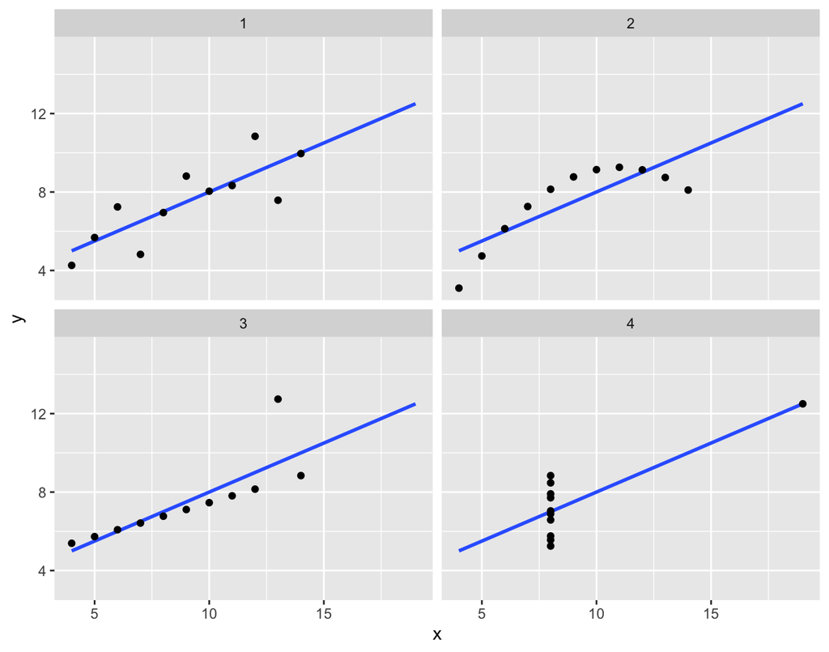

- The following four artificial datasets, referred to as Anscombe’s quartet, famously illustrate this point.
- All these pairs have a correlation of 0.82:
- To help us understand when correlation is meaningful as a summary statistic, we return to the example of predicting a son’s height using his father’s height.

## An Important Observation

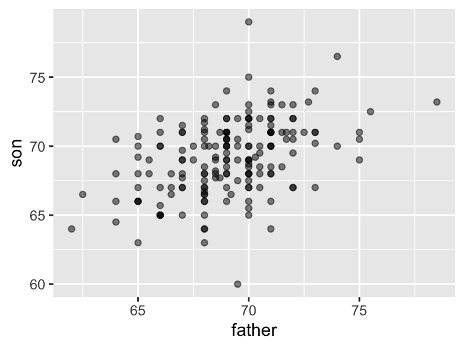

- notice that there is a strong relationship between the height of a father and his son
- we will get better estimates if we can use the height of the father
- statistical models are how we do that
- and we will first explore an *idea* called conditional expectation

## Conditional expectations

- Suppose we are asked to guess the height of a randomly selected son and we don’t know his father’s height.
- Because the distribution of sons’ heights is approximately normal, we know the average height, 69.2, is the value with the highest proportion and would be the prediction with the highest chance of minimizing the error.
- But what if we are told that the father is taller than average, say 72 inches tall, do we still guess 69.2 for the son?
- The statistical notation for the conditional expectation is:
  $$\mbox{E}(Y \mid X = x)$$
- with $x$ representing the fixed value that defines that subset, for example 72 inches.
- this represents the average value of the variable named $Y$ when the variable named $X$ has value $x$

## Conditional expectations

- we divide the data up into groups depending on the father’s height
- for each group we compute a boxplot
- when we examine the boxplots we see that the son’s heights really change depending on the father’s height

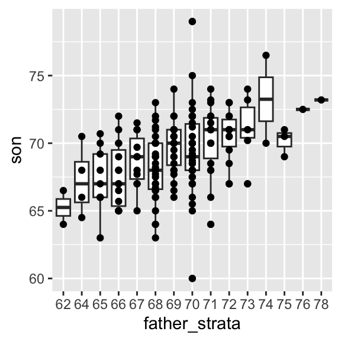

## Conditional expectations

- Here we plot the means of the son’s height for a binned value of the father’s height
- These would be reasonable estimates to use
- But they waste information and are less precise than they could be
- We introduce models as ways to be more specific about the form of the relationship between the y’s and the x’s **and** to improve the precision of our estimates

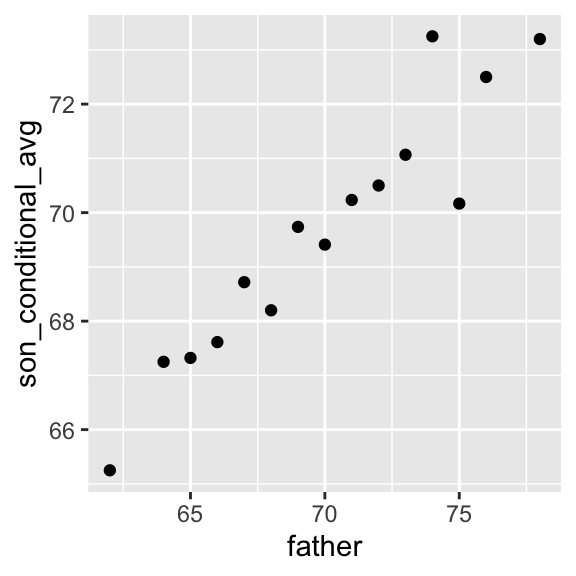

## Regression

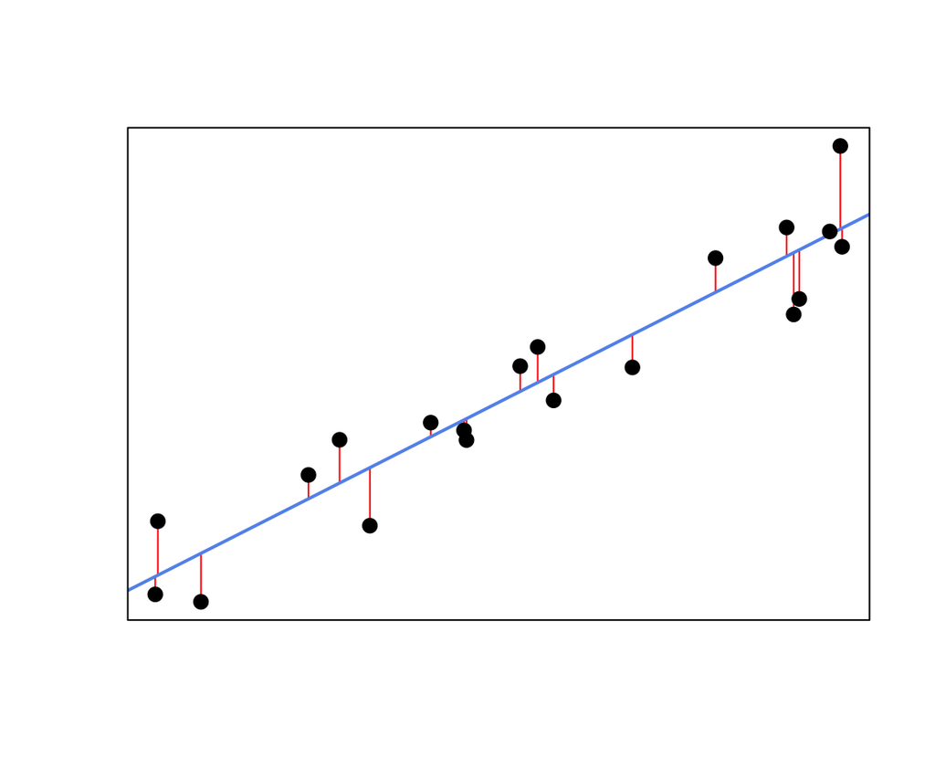

- the regression line is in blue
- the method used to estimate it is called least squares (LS)
- the LS solution minimizes the length of the red lines (they represent the *residuals*)
- we write this as $y = \alpha + \beta \cdot x + \epsilon$
- and our regression line is: $E[Y|x] = \widehat{\alpha} + \widehat{\beta} \cdot x$

## The regression line

- we can show that the estimates of the intercept $\widehat{\alpha}$ and the slope $\widehat{\beta}$ are good in a variety of ways
- and we can use the estimated regression line to make predictions
- $E[Y| x_{new}] = \widehat{\alpha} + \widehat{\beta} \cdot x_{new}$

## More general models

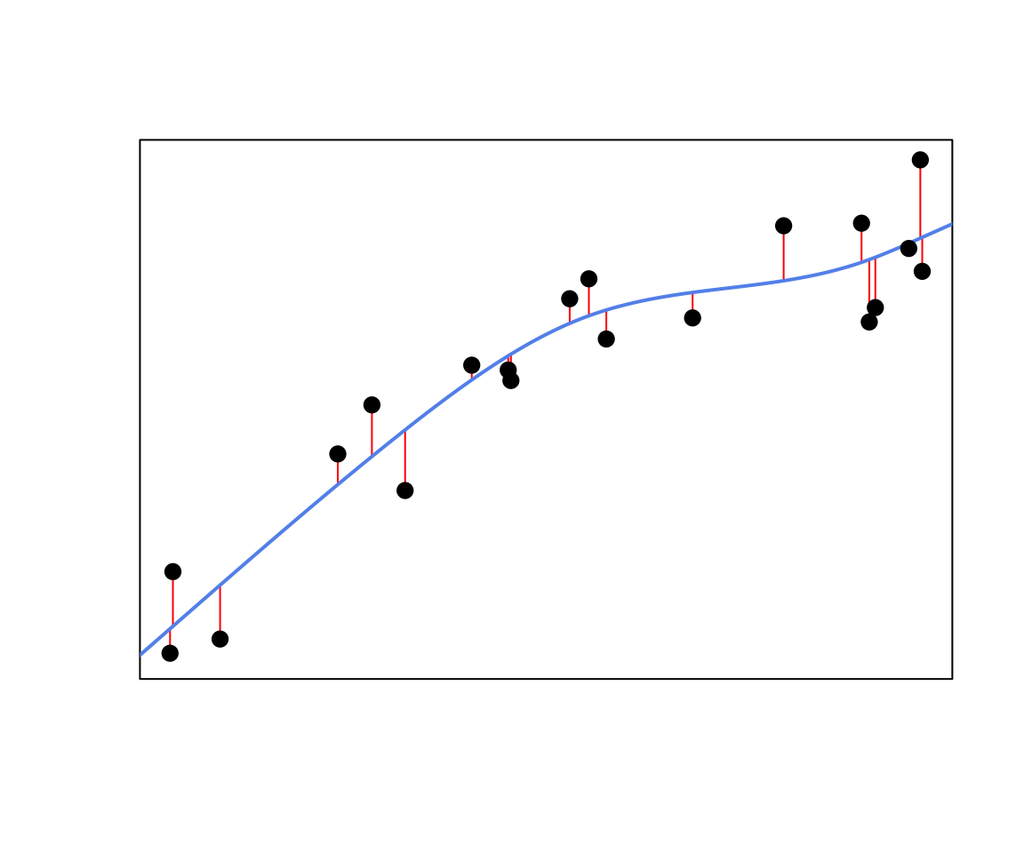

- we want to choose a candidate that is smooth (usually) and where we try to minize the distance between the observed data and the smooth fit
- then we have:

$E[Y|x] = s(x) + \epsilon$

$E[Y|x] = \widehat{s}(x)$

- predictions are

$E[Y|x_{new}] = \widehat{s}(x_{new})$

## How should we think about the changes in height

- when data are random we often don’t want to use the units they were measured in for comparisons
- the reason is that we want to make the same conclusions whether we measure height in inches or in meters
- so when the data are approximately Normal$(\mu, \sigma)$ we measure distance in units that correspond to $\sigma$
- the change in y is typically not assessed in the units of y (inches in our example)
- it is more important to think of the change as a function of the variability in y and specifically the number of “SDs”

## Conditional expectations

- A father that is 72 inches tall is about 1 SD taller than the mean height of fathers
- our prediction for the height of the son is: 70.5
- which is also taller than the average height of sons
- **but** only 0.49 standard deviations larger than the height of the average son.
- The sons of 72 inch fathers have *regressed* towards the average height.

## Regression improves precision

- Let’s compare the two approaches to prediction that we have presented:
  1. Round fathers’ heights to closest inch, stratify, and then take the average.
  2. Compute the regression line and use it to predict.
- We use a Monte Carlo simulation sampling $N=50$ families:

## Regression improves precision

```r
B <- 1000
N <- 50
set.seed(1983)
conditional_avg <- replicate(B, {
  dat <- sample_n(galton_heights, N)
  dat |> filter(round(father) == 72) |>
    summarize(avg = mean(son)) |>
    pull(avg)
  })
regression_prediction <- replicate(B, {
  dat <- sample_n(galton_heights, N)
  mu_x <- mean(dat$father)
  mu_y <- mean(dat$son)
  s_x <- sd(dat$father)
  s_y <- sd(dat$son)
  r <- cor(dat$father, dat$son)
  mu_y + r*(72 - mu_x)/s_x*s_y
})
```

- Although the expected value of these two random variables is about the same:

```r
mean(conditional_avg, na.rm = TRUE)
```

```
[1] 70.5
```

```r
mean(regression_prediction)
```

```
[1] 70.5
```

- The standard error for the regression prediction is substantially smaller:

```r
sd(conditional_avg, na.rm = TRUE)
```

```
[1] 0.964
```

```r
sd(regression_prediction)
```

```
[1] 0.452
```

## Regression improves precision

- The prediction obtained with the regression line is therefore much more stable than the prediction obtained using the conditional mean.
- There is an intuitive reason for this.
- The conditional average is computed on a relatively small subset: the fathers that are about 72 inches tall.
- In fact, in some of the permutations we have no data, which is why we used `na.rm=TRUE` in our simulation.
- The regression line is estimated using all the data.

## Multivariate Regression

- if one variable is good - then **two** variables must be better….

$$Y = \alpha + \beta_1 X_1 + \beta_2 X_2 + \ldots + \beta_k X_k + \epsilon$$
where again we assume $\epsilon ~ N(0, \sigma^2)$

- we can fit these models using least squares as well to get estimates of the model parameters and make predictions
- as before we will need to engage in a substantial amount of model building and diagnostic assessment

## An Example: The Boston Housing Data

- data on housing prices as a market measure of the value people place on environmental quality.
- assumes that a home’s price reflects not only the house itself but also desirable neighborhood characteristics such as cleaner air, lower crime, better schools, and access to jobs.
- they hoped that by modeling house prices while controlling for these other characteristics, they could estimate the economic value of improved air quality.
- we will return to this data in the lab

## Boston Housing Data

| varname | meaning |
| --- | --- |
| zn | proportion of residential land zoned for lots over 25,000 sq.ft |
| indus | proportion of non-retail business acres per town |
| chas | Charles River proximity (1 if tract bounds river; 0 otherwise) |
| nox | nitrogen oxides concentration (parts per 10 million) |
| rm | average number of rooms per dwelling |
| age | proportion of owner-occupied units built prior to 1940 |
| dis | weighted mean of distances to five Boston employment centres |
| rad | index of accessibility to radial highways |
| tax | full-value property-tax rate per $10,000 |
| ptratio | pupil-teacher ratio by town |

[output cut: 3 more lines]

## Boston Housing Data

```r
fit1 <- lm(medv ~ dis + rm, data = Boston)
summary(fit1)
```

```
Call:
lm(formula = medv ~ dis + rm, data = Boston)

Residuals:
   Min     1Q Median     3Q    Max
-21.67  -2.98  -0.13   2.65  40.24

Coefficients:
            Estimate Std. Error t value             Pr(>|t|)
(Intercept)  -34.636      2.621  -13.21 < 0.0000000000000002 ***
dis            0.489      0.141    3.46              0.00059 ***
rm             8.801      0.424   20.78 < 0.0000000000000002 ***
---
Signif. codes:  0 '***' 0.001 '**' 0.01 '*' 0.05 '.' 0.1 ' ' 1

Residual standard error: 6.55 on 503 degrees of freedom
Multiple R-squared:  0.496, Adjusted R-squared:  0.494
F-statistic:  247 on 2 and 503 DF,  p-value: <0.0000000000000002
```

## Model diagnostics: Residual Plot

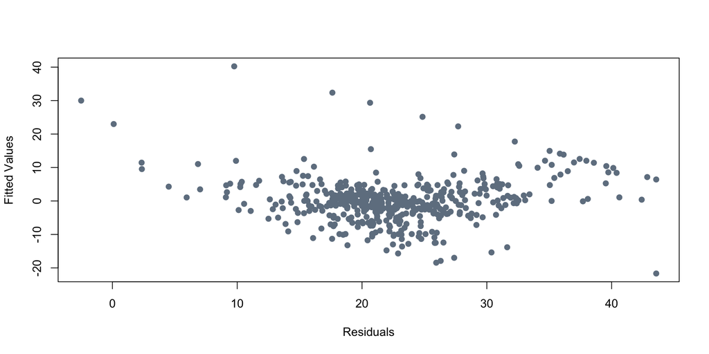

```r
plot(fit1$fitted.values, fit1$residuals, xlab="Residuals", ylab="Fitted Values", pch=19, col="slategrey")
```

## Pairs Plot

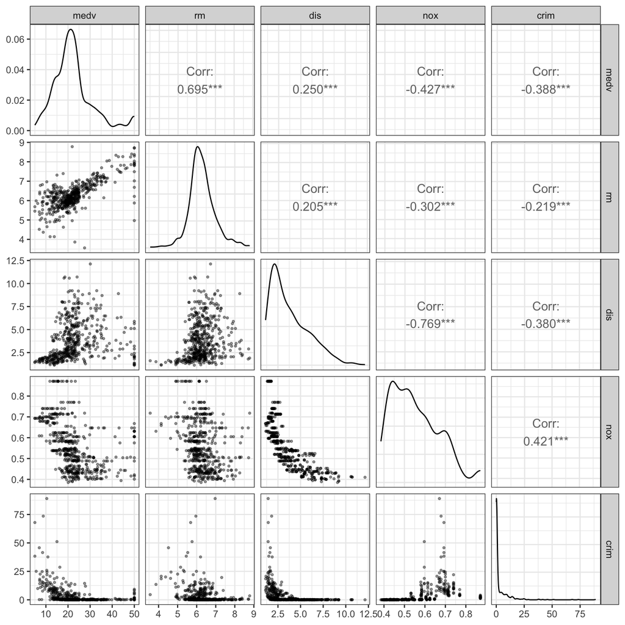

- notice the very odd behavior of some of the features
- there are outliers, limits of detection, non-linearty
- and potential interactions
- this is a challenge to fit and interpret

## Multivariate Regression: Interactions

- sometimes the effect of $X_i$ depends on the value (level) of $X_j$
- E.g. Smoking and asbestos each increase the risk of lung cancer, but together they produce a much greater increase than either exposure alone.
- if we believe there might be an interaction then we fit it by using special syntax, $X_i * X_j$

## Interactions

```r
fit1I <- lm(medv ~ dis + rm + lstat + rm*lstat, data = Boston)
summary(fit1I)
```

```
Call:
lm(formula = medv ~ dis + rm + lstat + rm * lstat, data = Boston)

Residuals:
    Min      1Q  Median      3Q     Max
-24.365  -2.612  -0.557   1.965  29.139

Coefficients:
            Estimate Std. Error t value             Pr(>|t|)
(Intercept) -24.7097     3.4073   -7.25      0.0000000000016 ***
dis          -0.5323     0.1135   -4.69      0.0000035196332 ***
rm            9.5110     0.4918   19.34 < 0.0000000000000002 ***
lstat         2.1407     0.2019   10.61 < 0.0000000000000002 ***
rm:lstat     -0.4918     0.0339  -14.50 < 0.0000000000000002 ***
---
Signif. codes:  0 '***' 0.001 '**' 0.01 '*' 0.05 '.' 0.1 ' ' 1

Residual standard error: 4.61 on 501 degrees of freedom
Multiple R-squared:  0.751, Adjusted R-squared:  0.749
F-statistic:  378 on 4 and 501 DF,  p-value: <0.0000000000000002
```

## Boston Housing Data

- We do two linear regressions with $y$ the house value, and two predictors (`dis` and `rm`), or three (in addition, `nox`).
- what changes?

```r
#fit1 <- lm(medv ~ dis + rm, data = Boston)
coef(fit1)
```

```
(Intercept)         dis          rm
    -34.636       0.489       8.801
```

```r
fit2 <- lm(medv ~ dis + rm + nox, data = Boston)
coef(fit2)
```

```
(Intercept)         dis          rm         nox
    -10.118      -0.663       8.097     -28.343
```

## Collinearity

```
Call:
lm(formula = medv ~ dis + rm + rad + tax, data = Boston)

Residuals:
   Min     1Q Median     3Q    Max
-16.62  -3.12  -0.48   2.31  41.75

Coefficients:
             Estimate Std. Error t value             Pr(>|t|)
(Intercept) -19.29174    3.15124   -6.12         0.0000000019 ***
dis          -0.18298    0.15307   -1.20                 0.23
rm            7.97354    0.40941   19.48 < 0.0000000000000002 ***
rad           0.06409    0.07618    0.84                 0.40
tax          -0.02010    0.00412   -4.88         0.0000014066 ***
---
Signif. codes:  0 '***' 0.001 '**' 0.01 '*' 0.05 '.' 0.1 ' ' 1

Residual standard error: 6.11 on 501 degrees of freedom
Multiple R-squared:  0.562, Adjusted R-squared:  0.559
F-statistic:  161 on 4 and 501 DF,  p-value: <0.0000000000000002
```

## Collinearity

- RAD – TAX have a correlation of about 0.9

```
Call:
lm(formula = medv ~ dis + rm + rad, data = Boston)

Residuals:
   Min     1Q Median     3Q    Max
-17.92  -3.17  -0.48   2.57  42.30

Coefficients:
            Estimate Std. Error t value             Pr(>|t|)
(Intercept) -27.8574     2.6768  -10.41 < 0.0000000000000002 ***
dis          -0.0242     0.1529   -0.16                 0.87
rm            8.4325     0.4074   20.70 < 0.0000000000000002 ***
rad          -0.2632     0.0370   -7.11       0.000000000004 ***
---
Signif. codes:  0 '***' 0.001 '**' 0.01 '*' 0.05 '.' 0.1 ' ' 1

Residual standard error: 6.25 on 502 degrees of freedom
Multiple R-squared:  0.542, Adjusted R-squared:  0.539
F-statistic:  198 on 3 and 502 DF,  p-value: <0.0000000000000002
```

## Simpson’s Paradox

- one of the reasons that we need to be careful with multivariate models is that the potential covariates have very particular effects

## Simpson’s Paradox

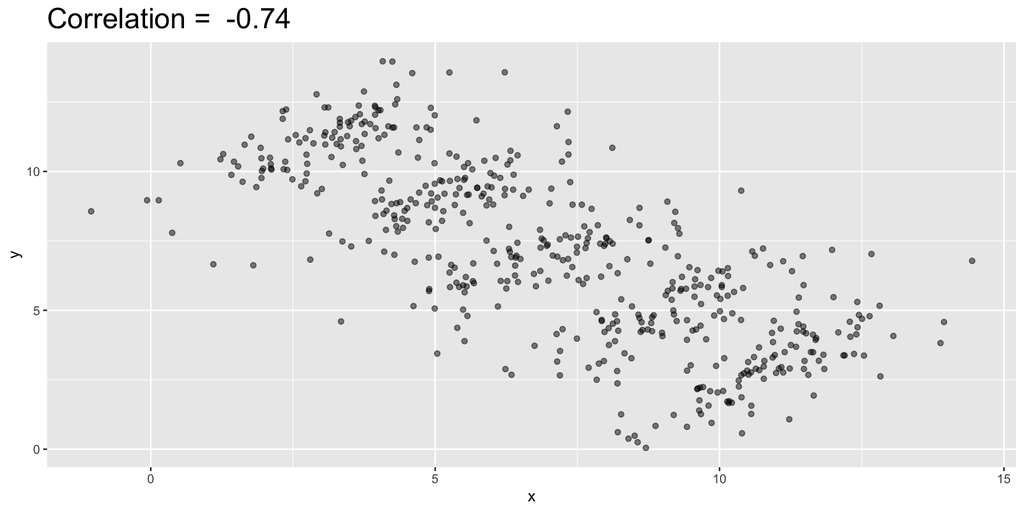

You can see that $X$ and $Y$ are negatively correlated. However, once we stratify by $Z$ (shown in different colors below), another pattern emerges:

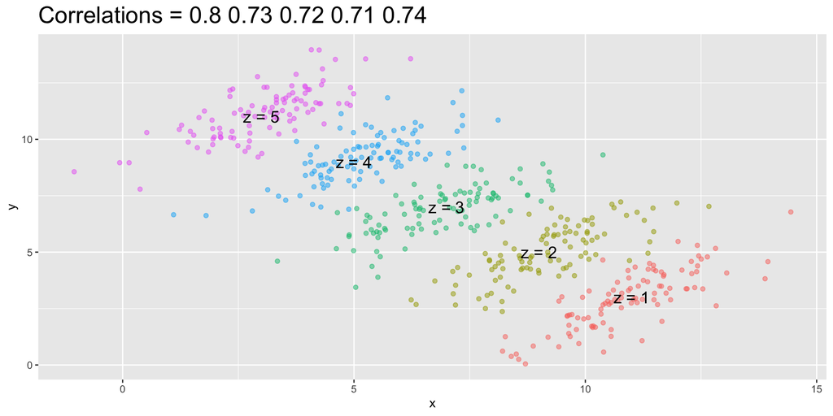

It is really $Z$ that is negatively correlated with $X$. If we stratify by $Z$, the $X$ and $Y$ are actually positively correlated, as seen in the plot above.

## Confounding

- When we are unable to randomly assign each individual to a treatment or control groups, confounding becomes particularly prevalent.
- Confounding occurs when a third variable is associated with both the exposure and the outcome, creating a misleading or distorted estimate of their relationship.
- A confounder is not part of the causal pathway and should be addressed through study design or analysis, such as randomization, restriction, matching, stratification, or regression adjustment.
- For instance, consider estimating the effect of eating fast foods on life expectancy using data collected from a random sample of people in New York City.
- Fast food consumers are more likely to be smokers, drinkers, and have lower incomes.
- Consequently, a naive regression model may lead to an overestimate of the negative health effects of fast food.

## Collider Bias

- when the selection process introduces a correlation when there is not one in the population
- Mary wants to find a boyfriend. But she has high standards and he must be either good looking or he must be smart
- She then notices that the smart boys are not that good looking and the good looking boys are not that smart.
- this happens in many situations - especially for example when studying diseases in hospitals
- being in hospital for something means that you probably have that disease, but not others